# Activity B: Prediction

Author

Jared Parker

Published

September 17, 2023

````markdown
```{r}
#| label: dataload
# Load the data into the dfb dataframe
dfb <- readr::read_csv(here("data.csv"))

# this is dfb because it's the data frame for activity B
comm <- dfb$comm # Create a vector of the communication data
peers <- dfb$peers # Create a vector of the peer relationship quality data
```
````

## Assignment description

````markdown
```{r}
#| label: tbl-tablemargin
#| column: margin
#| tbl-cap: Preview of data
# This is just to demonstrate how to use margin content. It will display the
# first 6 rows of the dfb dataframe in the right-hand margin.

dfb |>
  head() |>
  kable()
```
````

Table 1: Preview of data

| ID | comm | peers |
| --- | --- | --- |
| 1 | 4.0 | 5.2 |
| 2 | 5.0 | 5.8 |
| 3 | 6.7 | 4.9 |
| 4 | 4.0 | 7.0 |
| 5 | 4.0 | 5.2 |
| 6 | 4.9 | 5.9 |

> A researcher was interested in whether there was an association between communication skills and quality of peer relationships in third grade classrooms. Teachers in each class completed a communicative skills checklist and a rating scale of peer relations for each child. The items for each scale were averaged to provide an overall score for each child.

Provide an analysis and interpretation of this data produced in such a way that a non-statistician can understand it.

## Descriptive Statistics

````markdown
```{r}
#| label: structure
# This chunk will actually display the descriptives table but NOT overwrite it!
dfb |>
  select(-ID) |>                     # From the dplyr package in the tidyverse
  descr() |>                         # From the summarytools package
  kable()                            # From the knitr package
```
````

|  | comm | peers |
| --- | --- | --- |
| Mean | 5.1520000 | 4.8825000 |
| Std.Dev | 1.5905171 | 1.2698846 |
| Min | 1.0000000 | 1.0000000 |
| Q1 | 4.0000000 | 4.0000000 |
| Median | 5.0000000 | 4.9000000 |
| Q3 | 6.9000000 | 5.9000000 |
| Max | 7.0000000 | 7.0000000 |
| MAD | 1.5567300 | 1.3343400 |
| IQR | 2.9000000 | 1.9000000 |
| CV | 0.3087184 | 0.2600890 |
| Skewness | -0.5497406 | -0.3524526 |
| SE.Skewness | 0.1719248 | 0.1719248 |
| Kurtosis | -0.6045037 | -0.1451133 |
| N.Valid | 200.0000000 | 200.0000000 |
| Pct.Valid | 100.0000000 | 100.0000000 |

## Assignment responses

### Scatterplot

A **scatterplot** that displays the relationship between the **peers** and **comm** variables:

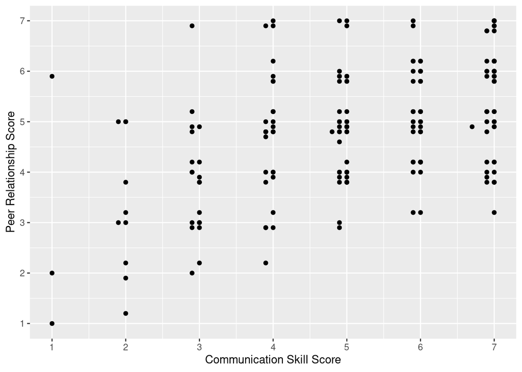

Scatterplot of Peer Relationships against Communication Skills

````markdown
```{r}
#| label: scatterplot
#| fig-cap: "Scatterplot of Peer Relationships against Communication Skills"
pcplot <- dfb |>
  ggplot(aes(x = comm, y = peers)) +
  geom_point() +
  scale_x_continuous(name = "Communication Skill Score", breaks = seq(0, 10, by = 1)) +
  scale_y_continuous(name = "Peer Relationship Score", breaks = seq(0, 10, by = 1)) +
  theme_grey()
pcplot
```
````

As *Communication skills* are honed by the third-graders, the *Quality of Peer Relationships* between them will generally increase, but there are plenty of data points that fall outside of this trend as well. The positive nature of this moderate linear relationship is visualized on the graph via the y-values increasing as the x-values increase. The amount of data points that are spread out lowers the strength of the association and makes it a moderate linear relationship, as can be seen in the graphs found in Lane (2015) chapter four.

Lane, D. (2015). Online Statistics Education: A Multimedia Course of Study (Chapter 4, pp. 167-174).

### Pearson correlation coefficient

````markdown
```{r}
#| label: pearson
pc <- cor(comm, peers, method = "pearson")
```
````

The *Pearson correlation coefficient* for the `peers` and `comm` variables is: 0.5064054

A *Pearson correlation coefficient* value of 0.5064054 illustrates a moderate linear relationship between the *Communication skills* and *Quality of Peer Relationships* found in third-graders. As a *correlation coefficient* of $1$ is a perfect linear relationship, and one of $0$ is no relationship, the 0.5064054 value is a demonstration of moderate linearity. The positive, left-skewed nature is due to the increase in *Quality of Peer Relationships* as *Communication skills* develop and grow. This supports the assertion, found above, that is based solely on the graph and provides concrete data to support the statement.

### R<sup>2</sup>, the coefficient of determination

````markdown
```{r}
#| label: r2
cd <- pc^2
```
````

The coefficient of determination is: 0.2564465

This value of 0.2564465 demonstrates the level of variability in the *Quality of Peer Relationships* that is caused by the *Communication skills* meaning that only a portion of the trends in the data is captured, while a large amount of the variability is unknown. A low coefficient of determination shows the overall weakness of the model between the *Communication skills* and *Quality of Peer Relationships* found in third-graders. This does not mean that there is no relationship between the two variables, as a correlation coefficient of 0.5064054 is a valid statistical measure for the moderate linear relationship seen, but it does suggest that there are other factors, not captured by the model, that are affecting the scores. This could be measurement error, inherent randomness, or other unknowns. While this may appear to inherently have more value than the statistical measures discussed earlier, the synergistic nature of those statistics produces a gestalt that cannot be denied. This is due to the one-sided perspective that only one statistic offers. If only the coefficient of determination is known, then only the degree of variability is known. If only the correlation value is known, then the true accuracy of the model will be unknown. While the scatterplot offers the most information quickly, it can be misleading as graphs often are. All three must be considered in tandem to draw valuable conclusions.

## References

Lane, David. 2015. *Online Statistics Education: A Multimedia Course of Study*.